# NAIP stats extraction

Kristin Braziunas

## Purpose

The purpose of this script is to extract consistent imagery metrics from NAIP data for use in fitting fuels regressions, predicting fuel loads in Berry Fire sample points (Q1 and Q2), and creating the final fuels map.

Parts of this script are not evaluated when knitted due to computation time.

```r
# load libraries
library(raster) # version 3.0-2
library(sf) # version 0.7-7
library(rgdal) # version 1.4-4
library(glcm) # version 1.6.5
library(dplyr) # version 0.8.3
library(grDevices) # version 3.6.1
library(RColorBrewer) # version 1.1-2

# running in parallel
library(parallel) # version 3.6.1
library(foreach) # version 1.4.7
library(doParallel) # version 1.0.15
```

## 1. Create image collection for NAIP files

NAIP files were downloaded from Wyoming GIS as slightly overlapping tiles. The first step here was creating a catalog (similar to the LiDAR catalog) that would enable easy matching up of NAIP tiles with plot footprints.

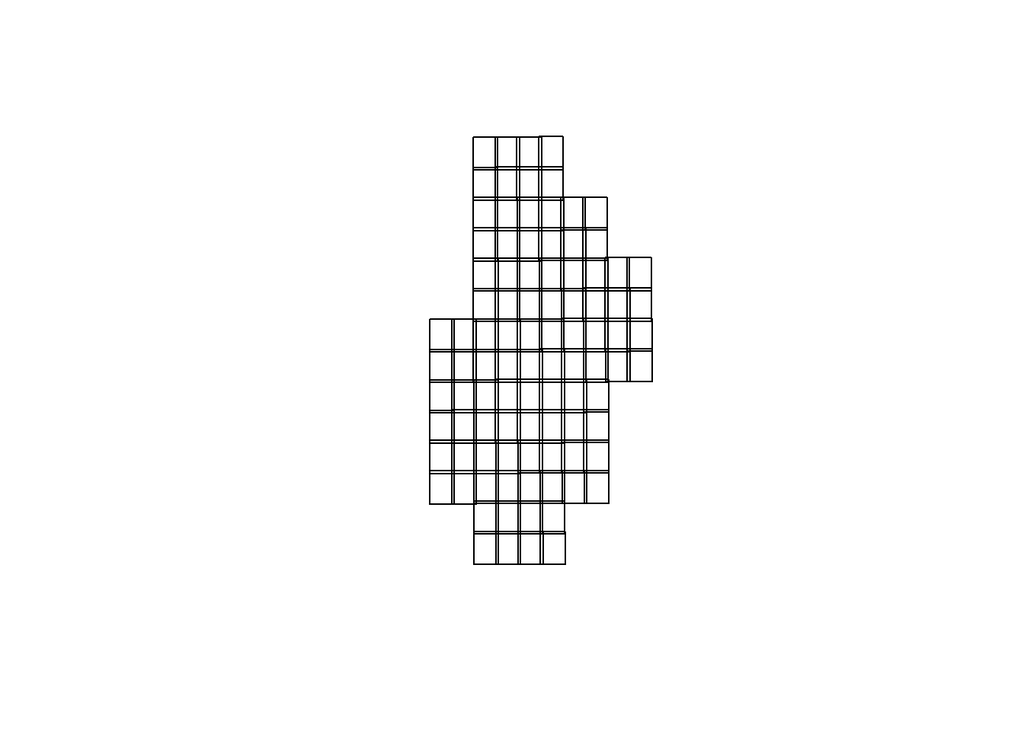

```r
# read in single image to set up blank spatial polygons data frame
naip.samp = stack("data/NAIP/BlueMinerLake2015/m_4311028_ne_12_h_20150912.tif")

# create blank sfc to hold naip extents
naip.out = st_sfc()
st_crs(naip.out) = crs(naip.samp)

# loop through list of folders matching usgs 24k topo maps
folds = list.files(path="data/NAIP/", pattern="2015", full.names=TRUE)

for(j in 1:length(folds)) {

  fold.in = folds[j]

  # loop through files in each topo map folder
  files = list.files(path=paste0(fold.in), pattern=".tif", full.names=TRUE)

  for(i in 1:length(files)) {

    file.in = files[i]

    # read in each naip image
    naip.in = stack(file.in)

    # convert the extent to a polygon
    naip.sp = st_as_sfc(st_bbox(naip.in))
    st_crs(naip.sp) = crs(naip.in)

    # add name of image
    naip.spdf = st_sf(file_name = file.in, geometry = naip.sp)

    # add to sfc
    naip.out = rbind(naip.out,naip.spdf)

  }

}


plot(st_geometry(naip.out))  # success!
```

```r
# set crs
st_crs(naip.out) = "+init=epsg:26912"
```

## 2. Load data

Load plot data from 2019 field data collection.

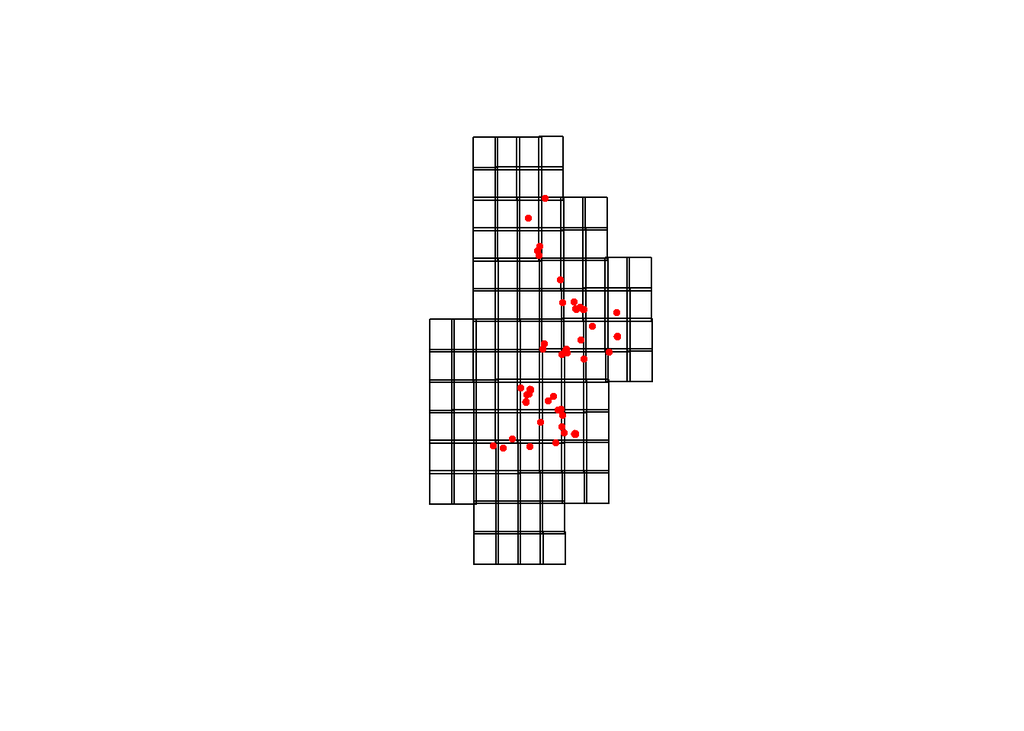

```r
# load and plot field plot footprints
field.shp = st_read("processed_data/field_plot_selection/final_plots/field_plots_polygons_2019.shp")

field.shp
plot(st_geometry(naip.out))
plot(field.shp[1], add=TRUE, border="red", lwd=5)
```

```r
# same crs as NAIP, but make sure the proj4strings "match"
st_crs(field.shp) = st_crs(naip.out)

# also shapefile for Q1 for BerryGlade
bg_q1 = st_read("processed_data/field_plot_selection/final_plots/berryglade_q1_polygon.shp")

st_crs(bg_q1) = st_crs(naip.out)
```

## 3. Identify NAIP tile corresponding to each plot

I identified the NAIP tile corresponding to each 2019 field plot. If the plot was in an area of overlap between two tiles, I chose the first tile and verified by plotting that this NAIP tile covered the entire plot footprint.

```r
naip.list = st_intersection(naip.out,field.shp)

# choose first item in this list with duplicated
# vet this below by plotting to ensure full coverage
naip.first = naip.list[!duplicated(naip.list$Plot_code),]

# check for full coverage
naip.check = naip.first

for(k in 1:length(naip.check$Plot_code)) {
  plot.in = naip.check[k,]$Plot_code

  # corresponding plot
  plot.sub = naip.first %>%
    filter(Plot_code==plot.in)

  # read in, crop and mask
  naip.in = stack(as.character(plot.sub$file_name))
  naip.crop = mask(crop(naip.in,plot.sub),plot.sub)

  # plot and compare
  plotRGB(naip.crop, r=1,g=2,b=3)
  plot(st_geometry(plot.sub),add=TRUE,border="yellow")

}

# looks good
```

## 4. Calculate imagery metrics for test plot

I used a test plot to ensure that imagery metrics were being calculated correctly.

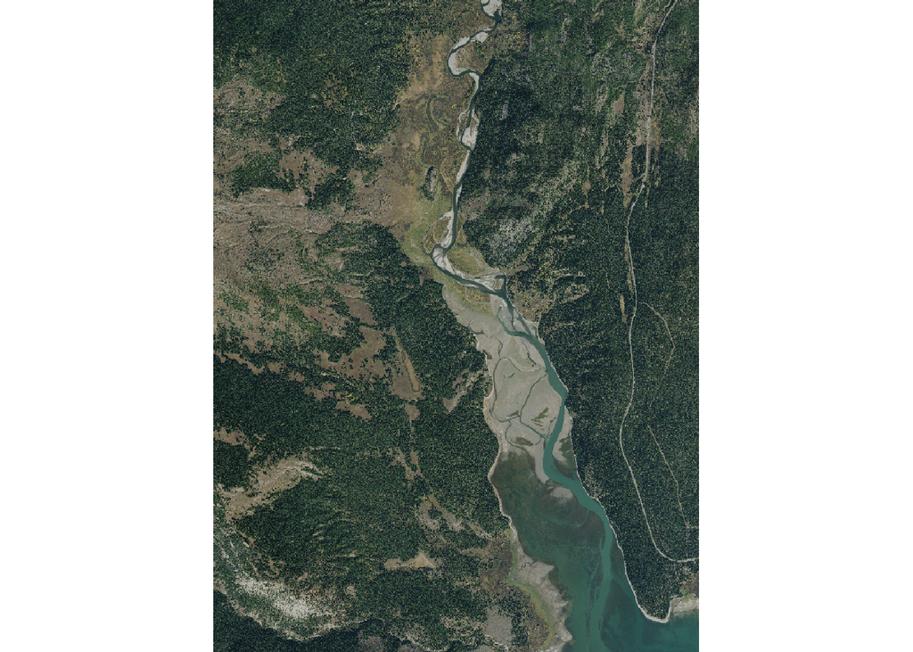

```r
### first test plots

# testing north side of park, choose naip should be SW Flagg Ranch, plot 33_2

flagg.sw = stack("data/NAIP/FlaggRanch2015/m_4411059_sw_12_h_20150924.tif")

plotRGB(flagg.sw, r=1,g=2,b=3)
```

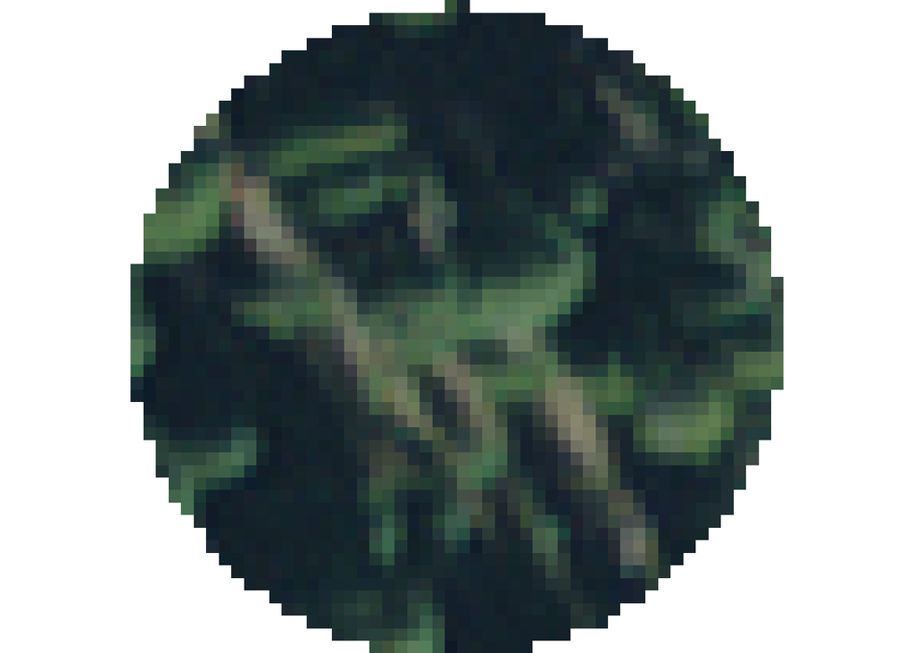

```r
con33 = field.shp %>%
  filter(Plot_code=="Con_33_2")

flagg.mask = mask(crop(flagg.sw,con33),con33)

plotRGB(flagg.mask, r=1,g=2,b=3)
```

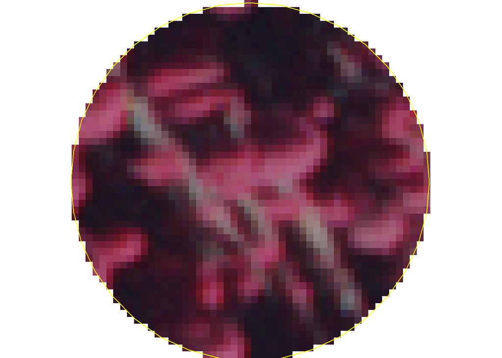

```r
plotRGB(flagg.mask, r=4,g=1,b=2)
plot(con33,add=TRUE,border="yellow",col=NA)
```

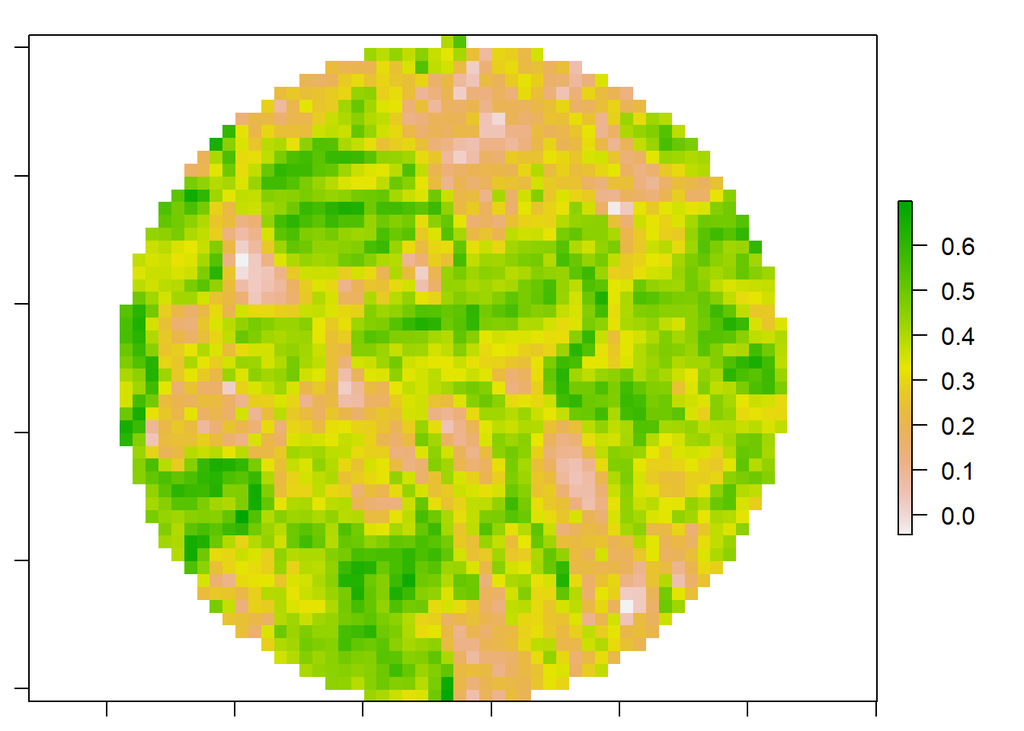

```r
# metadata
# spatial resolution: 0.5 m
# 4 bands: 1:R, 2:G, 3:B, 4:NIR
# ndvi is (NIR - R)/(NIR + R)
flagg.ndvi = (flagg.mask[[4]]-flagg.mask[[1]])/(flagg.mask[[4]]+flagg.mask[[1]])

plot(flagg.ndvi)
```

```r
# homogeneity
flagg.hom = glcm(flagg.ndvi, n_grey=32, window=c(7,7), statistics="homogeneity", min_x=-1, max_x=1)
flagg.hom = glcm(flagg.mask[[1]], n_grey=32, window=c(7,7), statistics="homogeneity", min_x=0, max_x=255)
cellStats(flagg.hom, stat="mean")
```

```
## [1] 0.5646272
```

## 5. Create function to extract imagery metrics

This function calculates imagery predictor metrics from a raster with a single band. The raster must already be masked to the plot footprint.

```r
### functions to get statistics from a given single band

get_rstats = function(r.in,bname, min.in, max.in) {

  # extracting all the same values as Erdody & Moskal 2010
  r.max = cellStats(r.in, stat="max")
  r.min = cellStats(r.in, stat="min")
  r.mean = cellStats(r.in, stat="mean")
  r.sd = cellStats(r.in,stat="sd")
  r.cv = (r.sd/r.mean) * 100

  # mean homogeneity based on a 32 grey levels (from Franklin & Moskal 2002), using a 7x7 window (Erdody & Moskal 2010), only within plot footprint, manually set max and min based on R, G, B, NIR, NDVI theoretical max and min
  r.hom = cellStats(glcm(r.in, n_grey=32, window=c(7,7), statistics="homogeneity", min_x=min.in, max_x=max.in),stat="mean")

  r.out = data.frame(r.max,r.min,r.mean,r.sd,r.cv,r.hom)
  names(r.out) = c(paste0(bname,"max"),paste0(bname,"min"),paste0(bname,"mean"),
                   paste0(bname,"sd"),paste0(bname,"cv"),paste0(bname,"hom"))

  return(r.out)

}
```

## 6. Derive NAIP metrics from 2019 field plots

I applied this function to derive imagery predictors for 2019 field plot footprints. For one plot in which trees were sampled in 1/4 of the plot, I used the shapefile for just that quadrant.

```r
### apply that function to all plots and generate dataframe of predictors

# blank dataframe
spectral.out = data.frame()

for(h in 1:length(naip.first$Plot_code)) {
  plot.h = naip.first[h,]$Plot_code

  # corresponding plot
  plot.sel = naip.first %>%
    filter(Plot_code==plot.h)

  # read in, crop and mask
  naip.full = stack(as.character(plot.sel$file_name))
  naip.mask = mask(crop(naip.full,plot.sel),plot.sel)

  # calculate ndvi
  naip.ndvi = (naip.mask[[4]]-naip.mask[[1]])/(naip.mask[[4]]+naip.mask[[1]])

  # get stats for R, G, B, NIR, and NDVI
  rstats = get_rstats(naip.mask[[1]],"R", min.in=0, max.in=255)
  gstats = get_rstats(naip.mask[[2]],"G", min.in=0, max.in=255)
  bstats= get_rstats(naip.mask[[3]],"B", min.in=0, max.in=255)
  nirstats = get_rstats(naip.mask[[4]],"NIR", min.in=0, max.in=255)
  ndvistats = get_rstats(naip.ndvi,"NDVI", min.in=-1, max.in=1)

  # combine
  allstats = cbind(rstats,gstats,bstats,nirstats,ndvistats)

  # add to output dataframe
  spectral.df = cbind(data.frame(Plot_code = plot.h), allstats)

  spectral.out = rbind(spectral.out,spectral.df)

  print(paste(plot.h, "complete"))

}

### read in, crop and mask BerryGlade Q1
naip.bg = stack("data/NAIP/FlaggRanch2015/m_4411059_nw_12_h_20150924.tif")
naip.q1 = mask(crop(naip.bg,bg_q1),bg_q1)

# calculate ndvi
ndvi.q1 = (naip.q1[[4]]-naip.q1[[1]])/(naip.q1[[4]]+naip.q1[[1]])

# get stats for R, G, B, NIR, and NDVI
rstats.q1 = get_rstats(naip.q1[[1]],"R",min.in=0, max.in=255)
gstats.q1 = get_rstats(naip.q1[[2]],"G",min.in=0, max.in=255)
bstats.q1= get_rstats(naip.q1[[3]],"B",min.in=0, max.in=255)
nirstats.q1 = get_rstats(naip.q1[[4]],"NIR",min.in=0, max.in=255)
ndvistats.q1 = get_rstats(ndvi.q1,"NDVI",min.in=-1, max.in=1)

# combine
allstats.q1 = cbind(rstats.q1,gstats.q1,bstats.q1,nirstats.q1,ndvistats.q1)

# add to output dataframe
spectral.dfq1 = cbind(data.frame(Plot_code = "Con_BerryGlade_Unburned3"), allstats.q1)

spectral.out = spectral.out %>%
  # remove full footprint first
  filter(Plot_code != "Con_BerryGlade_Unburned3") %>%
  rbind(spectral.dfq1)

# write out
write.csv(spectral.out,"processed_data/fuels_map_variables/naip_metrics.csv", row.names=FALSE)
```

## 7. Derive NAIP metrics for Berry Fire random samples (Q1, Q2)

Before applying the same function to derive imagery metrics from Berry Fire grid cell footprints, I added a manual check to make sure the NAIP tile always completely overlapped the plot footprint; this only was a concern near the edges of NAIP tiles, and when a plot was not completely covered, the overlapping NAIP tile was chosen instead. The same set of predictor metrics were derived for Berry Fire randomly sampled grid cells using plot footprints corresponding with the Berry Fire severity raster.

```r
# read in polys
age.polys = st_read("processed_data/Berry_Fire_sample_polys/berry_fire_age_sample.shp")
wx.polys = st_read("processed_data/Berry_Fire_sample_polys/berry_fire_wx_sample.shp")

st_crs(age.polys) = st_crs(naip.out)
st_crs(wx.polys) = st_crs(naip.out)

# match up with naip, double check that full footprint covered
# identify naip tif
age.naiplist = st_intersection(age.polys, naip.out)
wx.naiplist = st_intersection(wx.polys, naip.out)

# take first, remove duplicates
age.first = age.naiplist[!duplicated(age.naiplist$sample_id),]
wx.first = wx.naiplist[!duplicated(wx.naiplist$sample_id),]

# use function to check area and select 2nd image if first one incomplete coverage
check_area = function(list.in, first.in) {

  berry.naiplist = list.in
  berry.first = first.in

  area.out= data.frame()

  for(k in 1:length(berry.first$sample_id)) {
    plot.in = berry.first[k,]$sample_id

    # corresponding plot
    plot.sub = berry.first %>%
      filter(sample_id==plot.in)

    # read in, crop and mask
    naip.in = stack(as.character(plot.sub$file_name))
    naip.crop = mask(crop(naip.in,plot.sub),plot.sub)

    naip.ncells = data.frame(x = values(naip.crop[[1]])[!is.na(values(naip.crop[[1]]))]) %>%
      tally()

    naip.area = naip.ncells * 0.25

    area.out = rbind(area.out, data.frame(sample_id = plot.in, file_name = as.character(plot.sub$file_name), area =naip.area$n))
    # plot and compare
    plotRGB(naip.crop, r=1,g=2,b=3)
    plot(st_geometry(plot.sub),add=TRUE,border="yellow")

    # if something is missing, go to the next
    if(naip.area > 898) {

      print("full coverage")

    } else if (naip.area <= 898) {

      berry.naip2 = berry.naiplist[berry.naiplist$sample_id==plot.in,][2,]

      # read in, crop and mask
      naip.in2 = stack(as.character(berry.naip2$file_name))
      naip.crop2 = mask(crop(naip.in2,berry.naip2),berry.naip2)

      plotRGB(naip.crop2, r=1,g=2,b=3)
      plot(st_geometry(berry.naip2),add=TRUE,border="yellow")

      naip.ncells2 = data.frame(x = values(naip.crop2[[1]])[!is.na(values(naip.crop2[[1]]))]) %>%
        tally()

      naip.area2 = naip.ncells2 * 0.25

      # add this to berry.first
      berry.first = rbind(berry.first,berry.naip2)

      area.out = rbind(area.out, data.frame(sample_id = plot.in, file_name = as.character(berry.naip2$file_name), area =naip.area2$n))

      print(paste("replaced feature_nbr",plot.in))


    } else {
      print("error")
    }


  }

  return(area.out)
}


age.out = check_area(age.naiplist, age.first) %>%
  left_join(age.naiplist, by=c("file_name","sample_id")) %>%
  filter(area > 898)

wx.out = check_area(wx.naiplist, wx.first) %>%
  left_join(wx.naiplist, by=c("file_name","sample_id")) %>%
  filter(area > 898)


# extract predictors from each
# starting with above script, created new function to do this
berry_extract = function(berry.in) {

  berry.list = berry.in


  # blank dataframe
  spectral.out = data.frame()

  for(h in 1:length(berry.list$sample_id)) {
    plot.h = berry.list[h,]$sample_id

    # corresponding plot
    plot.sel = berry.list %>%
      filter(sample_id==plot.h) %>%
      st_as_sf()

    # read in, crop and mask
    naip.full = stack(as.character(plot.sel$file_name))
    naip.mask = mask(crop(naip.full,plot.sel),plot.sel)

    # calculate ndvi
    naip.ndvi = (naip.mask[[4]]-naip.mask[[1]])/(naip.mask[[4]]+naip.mask[[1]])

    # get stats for R, G, B, NIR, and NDVI
    rstats = get_rstats(naip.mask[[1]],"R", min.in=0, max.in=255)
    gstats = get_rstats(naip.mask[[2]],"G", min.in=0, max.in=255)
    bstats= get_rstats(naip.mask[[3]],"B", min.in=0, max.in=255)
    nirstats = get_rstats(naip.mask[[4]],"NIR", min.in=0, max.in=255)
    ndvistats = get_rstats(naip.ndvi,"NDVI", min.in=-1, max.in=1)

    # combine
    allstats = cbind(rstats,gstats,bstats,nirstats,ndvistats)

    # add to output dataframe
    spectral.df = cbind(data.frame(sample_id = plot.h), allstats)

    spectral.out = rbind(spectral.out,spectral.df)

    print(paste(plot.h, "complete"))

  }

  return(spectral.out)

}

spect.age = berry_extract(age.out) %>%
  right_join(age.out, by="sample_id") %>%
  dplyr::select(-geometry) %>%
  as.data.frame()

spect.wx = berry_extract(wx.out) %>%
  right_join(wx.out, by="sample_id") %>%
  dplyr::select(-geometry) %>%
  as.data.frame()


write.csv(spect.age, file="processed_data/Berry_Fire_sample_polys/berry_fire_age_naip.csv", row.names=FALSE)
write.csv(spect.wx, file="processed_data/Berry_Fire_sample_polys/berry_fire_wx_naip.csv", row.names=FALSE)
```

## 8. Imagery statistics for fuels map

For the fuels map, the LANDFIRE common grid is used to extract the same predictor variables described above at 30m resolution. This takes a long time, so first NAIP tiles are either excluded if outside the LiDAR data acquisition footprint (i.e., outside of GRTE, JODR, national elk refuge) and cropped as close to the boundary as possible. The process is then run in parallel. Rasters are first created in native CRS and then reprojected to NAD2011. These tiles are later mosaiced into a 30m raster covering the entire fuels map footprint (see step 07 script).

```r
# use same NAD2011 common grid as lidar

grte.nad2011 = raster("processed_data/GRTE_rasters/grte_30m_final_mask_nad2011.tif")
crs(grte.nad2011) = ("+init=epsg:6341") # set crs

# project to NAD83 to match NAIP
grte.nad83r = projectRaster(grte.nad2011, crs=crs(naip.out))

grte.nad83r

# function for final processing of each metric
naip_agg = function(r.in, fun.in, name.out) {
  # aggregate given raster and function
  naip.agg = raster::aggregate(r.in, fact=60, fun=fun.in, expand=FALSE)

  # resample and project to grte.crop grid
  r.resamp = raster::resample(naip.agg, grte.trim, method="ngb")
  r.nad2011 = raster::projectRaster(r.resamp, crs=raster::crs(grte.nad2011))

  # write final raster
  raster::writeRaster(r.nad2011, paste0("processed_data/GRTE_rasters/naip_tiles/",name.out,"_",corner.x,"_",corner.y,".tif"), format="GTiff")
}

# run in parallel

detectCores() # 8
cl = makeCluster(3) # use 3
registerDoParallel(cl)

# start of parallel operation
par.start = Sys.time()
print(par.start)

foreach(i=1:96) %dopar% {

# if not running in parallel can use
# for(i in c(41:44)) {

  start.time=Sys.time()
  print(start.time)

  # assign filename
  filename.in = as.character(naip.out[i,]$file_name)

  naip.in = raster::stack(filename.in)
  # plotRGB(naip.in)
  raster::crs(naip.in) = "+init=epsg:26912"

  # get information on corner
  corner.x = as.integer(raster::xmin(naip.in))
  corner.y = as.integer(raster::ymin(naip.in))

  # check if extents overlap, skip if not
  if(is.null(raster::intersect(raster::extent(naip.in), raster::extent(grte.nad83r)))) {
    print("extents do not overlap")
    next
  }

  # crop grte mask to naip tile and to shapefile
  grte.crop = raster::crop(grte.nad83r, naip.in[[1]])

  # skip to next if no data to grte.crop
  if(length(grte.crop[!is.na(raster::values(grte.crop))]) == 0) {
    print("outside park boundary, skipping tile")
    next
  }

  # calculate ndvi at 0.5 m resolution
  ndvi.layer = (naip.in[[4]]-naip.in[[1]])/(naip.in[[4]]+naip.in[[1]])
  names(ndvi.layer) = "ndvi"

  # add to stack
  naip.all = raster::stack(naip.in, ndvi.layer)

  # clean up
  rm(naip.in, ndvi.layer)

  print("ndvi calculated")

  # trim raster to remove na area from subsequent calculations
  grte.trim = raster::trim(grte.crop)

  # line up as close as possible, leave snap as "near"
  naip.crop = raster::crop(naip.all, grte.trim)

  # clean up
  rm(naip.all, grte.crop)

  print(paste0("calculating homogeneity for",raster::ncell(naip.crop),"cells"))

  # calculate homogeneity in 7x7 moving window
  hom1 = glcm::glcm(naip.crop[[1]], n_grey=32, window=c(7,7), statistics="homogeneity", min_x=0, max_x=255)
  print("hom1 done")
  hom2 = glcm::glcm(naip.crop[[2]], n_grey=32, window=c(7,7), statistics="homogeneity", min_x=0, max_x=255)
  print("hom2 done")
  hom3 = glcm::glcm(naip.crop[[3]], n_grey=32, window=c(7,7), statistics="homogeneity", min_x=0, max_x=255)
  print("hom3 done")
  hom4 = glcm::glcm(naip.crop[[4]], n_grey=32, window=c(7,7), statistics="homogeneity", min_x=0, max_x=255)
  print("hom4 done")
  hom5 = glcm::glcm(naip.crop[[5]], n_grey=32, window=c(7,7), statistics="homogeneity", min_x=-1, max_x=1)

  hom.stack = raster::stack(hom1,hom2,hom3,hom4,hom5)
  names(hom.stack) = c("band_1","band_2","band_3","band_4","ndvi")
  # clean up
  rm(hom1, hom2, hom3, hom4, hom5)

  print("homogeneity calculated")

  # looks good, now aggregate to 30m for all variables of interest

  naip_agg(naip.crop,"max","band_max")
  naip_agg(naip.crop,"min","band_min")
  naip_agg(naip.crop,"mean","band_mean")
  naip_agg(naip.crop,"sd","band_sd")
  naip_agg(hom.stack,"mean","band_hom")

  # will calculate CV later using raster math

  print(paste("done with file number",i,"name", filename.in))


  end.time = Sys.time()

  print(end.time-start.time)

}

stopCluster(cl)
```